# Workbook_V3

[figure not shown]

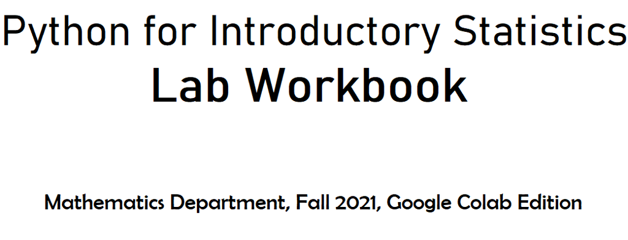

**Student's Lab Workbook**: A companion to [Python for Introductory Statistics](https://colab.research.google.com/drive/1KUWhhadNOGZTuWEVEU6EIK3J5zDBXAtN?usp=sharing)

Questions, comments or errors can be reported by sending an email to saman2@ccc.edu. A link to an interactive Colab version of this document can be found in this [interactive Colab workbook](https://colab.research.google.com/drive/1h_6TRQQGW8-RKsrqDaJOFtCQre-FCY9h?usp=sharing).

**Keyboard Shortcut for HTML (Weblink) and PDF Users**: When you click an external link and want to return to where you were before the click, use `Alt` + `Left Arrow` on Windows and `Command` + `Left Arrow` on Mac.

© 2021 Simon Aman, City Colleges of Chicago. Special thanks to reviewers, Professor Phil Yates of DePaul University and Professor Aman Ghebremicael of Arizona Western College.

This work is licensed under a [Creative Commons Attribution 4.0 International License (CC BY 4.0)](https://creativecommons.org/licenses/by/4.0/).

## Table of Contents

1. Introduction to Python
   - 1.1 Getting Started
   - 1.2 Python Arithmetic Operators
   - 1.3 Python Variables
   - 1.4 Python Comments
   - 1.5 The Numpy Library
   - 1.6 `input` Data From Keyboard
2. Python Lists
   - 2.1 Creating and Accessing Lists
   - 2.2 List Operations
3. Python Syntax
   - 3.1 Python `if` statements
   - 3.2 Python functions
   - 3.3 Syntax Errors
4. Python Loops
   - 4.1 The `for` Loop
   - 4.2 The `while` Loop
5. Frequency Distribution and Graphs
   - 5.1 Frequency Distributions
   - 5.3 Bar Graphs and Pie Charts
   - 5.4 Histogram, Polygon and Ogive
   - 5.5 Dot Plot
   - 5.5 Stem and Leaf Plot
6. Measures of Center and Variation
- 6.1 Mean and Median
- 6.2 Variance and Standard Deviation
- 6.4 Grouped Mean and Standard Deviation
7. Measures of Position
   - 7.1 Percentiles
   - 7.2 SciPy and Percentile Rank
   - 7.3 Box Plot
8. Discrete Probability Distributions
- 8.1 Expected Values and Standard Deviations
- 8.2 Binomial Probability Distribution
9. Continuous Probability Distribution
   - 9.1 Uniform Probability Distribution
   - 9.2 Normal Probability Distribution
   - 9.3 Central Limit Theorem: Mean
10. Confidence Intervals
- 10.1 Confidence Interval for Mean (z distribution)
- 10.2 Confidence Interval for Mean (t distribution)
- 10.3 Confidence Interval for Proportions
11. Hypothesis Testing
- 11.1 Hypothesis Testing: Mean z test
- 11.2 Hypothesis Testing: Mean t test
- 11.3 Hypothesis Testing: Proportion z test
12. Linear Regression and Correlation
- 12.1 Scatter Plot
- 12.2 Correlation
- 12.3 Linear Regression
13. Analysis of Categorical Data
    - 13.1 Goodness of Fit
    - 13.2 Test of Independence
14. Advanced Topics
- 14.1 Descriptive Statistics with Pandas
- 14.2 Uploading Excel Data
- 14.3 Visualization
- 14.4 Regression
- 14.5 ANOVA
- Lab Answers
- Appendix 1
- Appendix 2
- Appendix 3
- References
- Resources Link

# 1. Introduction to Python

Python is a general-purpose simple-syntax programming language created by Guido van Rossum in 1989. It is used in scientific computing, data science, web development, software development, artificial intelligence, machine learning etc.

## 1.1. Getting Started

**Google Colaboratory Notebook** (**Colab** for short) is a free web-based Google product, similar to Google Docs, that requires no software installation for Python programming. A Colab Notebook is a list of **cells** created by adding a **code** or a **text** cell. When you create your own Colab notebooks, they are stored in your Google Drive account.

### To Open a New Colab Notebook

[Watch demo video](https://youtu.be/2tYSkFevQdU)

1. Click [this link](http://colab.research.google.com#create=true).
2. Sign in with your Google account. If you are already signed in, continue to the next step. You can create a free [Google account](https://accounts.google.com/SignUp?hl=en).
3. Click **New Notebook** from the bottom-right of the pop-up window. Note: It may open a new notebook automatically sometimes.

**Note**: Google Colab Notebook (Picture Below)

[figure not shown]

### To Write Your First Python Code

1. Click the code-cell next to the `play` button
2. Type `print("Hello, World!")`

See picture below

[figure not shown]

### To Execute(run) Your First Python Code

1. Click the `play` button located before `print("Hello, World!")`
2. Or click on your first Python code and press Ctrl and Enter on your keyboard. Command and Enter for Mac(Apple) computers.
3. `Hello, world!` is displayed on a new line

[figure not shown]

### To Edit the Code

1. Click the code-cell with `print("Hello, World!)"`
2. Start editing

### To Write Your Second Python Code

1. Click `+ Code` in your notebook
2. Type `10+10` in the new code cell
3. Click the `play` button
4. The output `20` is displayed on a new line

[figure not shown]

**Note**: If you prefer **not** to use Google Colab Notebook, you can install free Python in your computer. See appendix 1 for details.

## Python Arithmetic Operators

| Name | Operator | Example | Result |
| --- | --- | --- | --- |
| Addition | `+` | `5+6` | `11` |
| Subtraction | `-` | 5-6 | `-1` |
| Multiplication | `*` | `5*6` | `30` |
| Division | `/` | `5/6` | `0.83333` |
| Exponentiation | `**` | `5**2` | $5^2$ =`25` |

### To Write Your Third Python Code

$7\times95$

1. Click `+ Code` on a notebook to add a code cell
2. Type `7*95`
3. Press the `play` button to execute the code
4. `665` is the result

[figure not shown]

### To Save Your Colab Notebook

[Watch demo video](https://youtu.be/wIiwVwdJaCM)

1. Click `Untitled.ipynb` at the top of the notebook
2. Delete the title and replace it by typing `python1`
3. Press the `enter` key
4. The file `python1` is now saved in your Google Drive
5. Click File and then Save
6. Close your browser

[figure not shown]

### To Open Your python1 Notebook

1. Click [this link](http://colab.research.google.com#create=true) or go to your [Google Drive](https://drive.google.com/).
2. Click `python1` from the list on the pop-up window
3. The notebook will open

OR click File menu then Open Notebook

[figure not shown]

**General Direction**: For the lab questions below:

1. Add a new code-cell on a Colab notebook
2. Type the code based on the statement of the lab
3. Execute the code

**Lab 1.1.1**

Add a code-cell and type `print("Hello, Python!")` and press the `play` button.

view answer

```python
print("Hello, Python!")
```

**Lab 1.1.2**

Add a code-cell to your Colab notebook and write a Python code that displays the phrase " `Welcome to Python Programming Language.`"

view answer

## 1.2 Python Arithmetic Operators

| Name | Operator | Example | Result |
| --- | --- | --- | --- |
| Addition | `+` | `5+6` | `11` |
| Subtraction | `-` | 5-6 | `-1` |
| Multiplication | `*` | `5*6` | `30` |
| Division | `/` | `5/6` | `0.83333` |
| Exponentiation | `**` | `5**2` | $5^2$ =`25` |

**Lab 1.2.1**

Add a code-cell, type `10 + 10`, and click the `play` button to the left of `10 + 10`.

view answer

```python
10+10
```

**Lab 1.2.2**

Write a Python code to find the value of $100-88$.

view answer

**Lab 1.2.3**

Write a Python code to perform the operation $\frac{1}{2}+ 7.1 - 10\times3$. On a code-cell type `1/2 + 7.1 - 10*3` and run (execute) the code by pressing the Ctrl+Enter or click the `play` button.

view answer

**Lab 1.2.4**

Write a Python code to perform the operation $-5+7-\frac{100+0.05}{10}$.

view answer

**Lab 1.2.5**

Write a Python code to perform the operation $\frac{1}{671000000}$.

view answer

**Lab 1.2.6**

For the year 2021, the Illinois state tax is 6.25%. How much state tax will one pay for a car priced at $16,000? Write a Python code to calculate the tax.

view answer

**Lab 1.2.7**

Write a Python code to evaluate: $28/4\times2$.

view answer

[Watch demo video](https://youtu.be/xHP1W-f94Us)

**Lab 1.2.8**

Write a Python code to perform the operation: $7^2+\frac{1}{\sqrt2}$.

view answer

**Lab 1.2.9**

Write a code for: $7^2-\sqrt 8$

view answer

**Lab 1.2.10**

Write a code to evaluate: $\frac{7^2-\sqrt 8}{25}$

view answer

## 1.3 Python Variables

[Watch demo video](https://youtu.be/Afee6voBzkA)

**Lab 1.3.1**

Given the ordered pairs `(6,9)` and `(5,1)`, write a Python code to find the slope and midpoint.

view answer

**Lab 1.3.2**

To solve a quadratic equation of the form $ax^2+bx+c=0$, we can use the formula below:

$x=\frac{-b - \sqrt{b^2-4ac}}{2a}$ or $x=\frac{-b + \sqrt{b^2-4ac}}{2a}$

Write a Python code to solve $2x^2-3x-4$ using the quadratic formula.

view answer

**Lab 1.3.3**

Evaluate $\frac{1+2}{18}$ and round the result to one decimal place.

view answer

## 1.4 Python Comments

**Lab 1.4.1**

view answer

## The Numpy Library

[Watch demo video](https://youtu.be/jhA5dbrmAXs)

**Lab 1.5.1**

Write a code to perform the operations: $|7\times 2 - \sqrt {89}|$

view answer

**Lab 1.5.2**

Write a code to evaluate: $\frac{|7^2-\sqrt 8|}{25}$

view answer

**Lab 1.5.3**

The area of a triangle with two sides of $a$ & $b$ and an angle between the two sides $C$ is given by the formula $A=a\times b\times\sin(C)$. Where $\sin(C)$ is the value of the sine function at $C$.

Find the area of a triangle with sides 10 and 12 inches and included angle of $\frac{\pi}{3}$.

view answer

**Lab 1.5.4**

Write a Python code to perform the operations: $\sqrt{6^2-4\times2\times(-5)}$

view answer

## 1.6 `input` Data From Keyboard

[Watch demo video](https://youtu.be/ism7PT9hAhI)

**Lab 1.6.1**

Write a Python code that asks an adult user to provide weight and height. Use those values to compute the BMI. Weight in lbs and height in foot and inches.

view answer

# 2. Python List

[Watch demo video](https://youtu.be/SClBYDOqN-E)

## 2.1 Creating and Accessing Lists

**Lab 2.1.1**

Write a Python code to create a Python **list** containing the following items: `1,2,3,4,5,6,7,8,9`

- Display all items

view answer

**Lab 2.1.2**

Write a Python code to create a Python **list** contianing the following items: `1,2,3,4,5,6,7,8,9`

- Display the first item

view answer

**Lab 2.1.3**

Write a Python code to list the following items: `1,2,3,4,5,6,7,8,9`

- Display the last item

view answer

**Lab 2.1.4**

Write a Python code to create a Python **list** containing the following items: `1,2,3,4,5,6,7,8,9`

- Display from 2nd to 4th items.

view answer

## 2.2 List Operations

**Lab 2.2.1**

Create a Python list using the ages of US Supreme Course Judges (as of 2021):`72,82,66,70,66,60,53,56,49`

- write a Python code to sort the ages

view answer

**Lab 2.2.2**

Create a Python list using the ages of US Supreme Course Judges (as of 2021):`72,82,66,70,66,60,53,56,49`

- write a Python code to display the oldest age

view answer

**Lab 2.2.3**

Create a Python list using the ages of US Supreme Course Judges (as of 2021):`72,82,66,70,66,60,53,56,49`

- write a Python code to display a list from the oldest to the youngest

view answer

# 3. Python Syntax

## 3.1 `if` statements

[Watch demo video](https://youtu.be/V3sWrUXzvOg)

**Lab 3.1.1**

Write a code that checks if the quadratic equation $x^2+3x+4=0$ has one, two or no real solutions.

view answer

**Lab 3.1.2**

Write a code that checks if the quadratic equation $5x^2+3x-16=0$ has one, two or no real solutions.

view answer

## 3.2 Python Functions

[Watch demo video](https://youtu.be/mrccPSioPu4)

Example: Given $a, b, c$, and the quadratic equation $ax^2+bx+C=0$. write a `function` to solve such equations. See answer in the code-cell below.

```python
def quadra(a,b,c):
  a,b,c = float(a),float(b),float(c)   # three lines in one
  if b**2-4*a*c < 0:
    return print("No real solutions")
  elif b**2-4*a*c == 0:
    x1 = -b/(2*a)
    return print("the solution is", x1)
  else:
    x1 = (-b-(b**2-4*a*c)**.5)/(2*a)
    x2 = (-b+(b**2-4*a*c)**.5)/(2*a)
    return print("the solutions are: ",x1," and ",x2)
```

**Lab 3.2.1**

Use the `quadra(a,b,c)` function above to solve $-x^2-x+10=0$.

view answer

**Lab 3.2.2**

Use the `quadra(a,b,c)` function to solve $x^2+x+1=0$.

view answer

## 3.3 Syntax Errors

[Watch demo video](https://youtu.be/i16E0LUCGGg)

**Lab 3.3.1**

Identify the error

```
b=2
 c=4
b/c
```

view answer

**Lab 3.3.2**

Identify the error in the code below:

```
a = 1
b = 2
if a > b
 print("a is bigger than b")
elif a == b:
 print("equal")
else:
 print("a is smaller than b")
```

view answer

**Lab 3.3.3**

Identify the error

```
a = 1
b = 2
if a > b:
 print("a is bigger than b")
elif a = b:
 print("equal)
else:
 print("a is smaller than b")
```

view answer

**Lab 3.3.4**

Identify the error

```
a = 1
b = 2
if a > b:
 print("a is bigger than b")
elif a == b:
 print("equal)
else:
 print("a is smaller than b")
```

view answer

# 4. Python Loops

There are two type of loops (repeated execution of statements): `for` and `while` loops

## 4.1 The `for` Loop

[Watch demo video 1](https://youtu.be/aJUlLZfjVbQ)

[Watch demo video 2](https://youtu.be/5WvWTbweFDo)

**Lab 4.1.1**

Use the `for` loop to find the average age of the IL Supreme Court Justices given the list of ages: `x=[77, 72,73,62,77,55]`.

view answer

## 4.2 The `while` Loop

**Example**

`while` loop for Fibonacci Numbers

Fibonacci Numbers: 1, 1, 2, 3, 5, 8, 13, 21, 34, 55, 89, 144, â€¦

The first two terms are 1 and 1. All other terms are obtained by adding the preceding two terms.

Below is a code that lists Fibonacci numbers up to a user given count.

```python
# type in the number of Fibonacci number you want to list and press enter.
n = input("How many Fibonacci numbers? Type a number and press enter. ")

n = int(n)              # convert it to an integer

i = 0                   # set i to zero initially
a = 1                   # first number is 1
b = 1                   # second number is 1

while i < n:            # i starts at zero and ends at n-1
    print (a)
    i = i + 1
    c = a + b          # sum assigned to c
    a = b              # second assigned to first
    b = c              # sum assigned to second
```

```
How many Fibonacci numbers? Type a number and press enter. 5
1
1
2
3
5
```

**Lab 4.2.1**

List the first 20 Fibonacci numbers.

view answer

**Lab 4.2.2**

Write a Python code that lists all positive integers starting from 1 till a user given number.

view answer

# 5. Frequency Distributions and Graphs

## 5.1 Frequency Distributions

[Watch demo video 1](https://youtu.be/hCihG4VmFGk)

[Watch demo video 2](https://youtu.be/JYgEzk4LSTQ)

[Watch demo video 3](https://youtu.be/_TaA9uA-E0U)

**Lab 5.1.1**

Write a Python code to find the frequency counts of the following data: `20, 21, 25, 20, 29, 25, 22, 25, 21, 25`

view answer

**Lab 5.1.2**

20 students were asked if they were registered to vote. Their responses are listed below. Construct a frequency distribution.

`NO, NO, YES, YES, NO, YES, NO, NO, YES, NO, YES, NO, NO, YES, YES, YES, YES, NO, YES, YES`

view answer

**Lab 5.1.3**

Write a Python code to construct a frequency distribution with 5 classes or bins for the following test scores:`40,40,40,40,40,41,41,41,41,41,41,42,42,42,42,43,43,43,43,43,43,44,44,44,44,45`.

view answer

## 5.3 Bar Graphs and Pie Charts

[Watch demo video 1](https://youtu.be/QsYU4o1yLJg)

[Watch demo video 2](https://youtu.be/N0kg36QPWzQ)

**Lab 5.3.1**

The latest number of coronavirus deaths (July 2021) in Chicago by race is given below. Write a Python code to construct a bar graph.

| Race | Deaths |
| --- | --- |
| Latinx | 1859 |
| Black | 2224 |
| White | 1233 |
| Other | 309 |

view answer

**Lab 5.3.2**

The latest number of coronavirus deaths in Chicago by race is given below. Write a Python code to construct a pie chart.

| Race | Deaths |
| --- | --- |
| Latinx | 1859 |
| Black | 2224 |
| White | 1233 |
| Other | 309 |

view answer

## 5.4 Histogram, Polygon and Ogive

[Watch demo video](https://youtu.be/L8d6GKv-95Y)

**Lab 5.4.1**

A random sample of 54 annual salaries of Aviation employees of the City of Chicago is listed below. Write a Python code to construct a histogram with 6 classes(bins).

`46776, 53736, 53736, 54840, 57408, 57408, 57408, 57408, 57408, 57408, 60108, 60108, 62712, 63552, 66852, 66852, 69732, 70032, 70044, 70272, 72024, 73380, 73380, 73380, 75408, 75468, 76248, 80484, 80484, 80484, 82476, 82788, 82836, 83676, 84324, 84324, 84324, 85848, 87564, 88272, 88272, 90828, 92004, 92304, 92520, 96060, 96096, 100680, 100716, 100716, 103764, 105420, 109620, 146868`

view answer

**Lab 5.4.2**

Example: A random sample of 54 annual salaries of Aviation employees of the City of Chicago is listed below. Write a Python code using `matplotlib` to construct a histogram with 6 classes(bins).

`46776, 53736, 53736, 54840, 57408, 57408, 57408, 57408, 57408, 57408, 60108, 60108, 62712, 63552, 66852, 66852, 69732, 70032, 70044, 70272, 72024, 73380, 73380, 73380, 75408, 75468, 76248, 80484, 80484, 80484, 82476, 82788, 82836, 83676, 84324, 84324, 84324, 85848, 87564, 88272, 88272, 90828, 92004, 92304, 92520, 96060, 96096, 100680, 100716, 100716, 103764, 105420, 109620, 146868`

view answer

**Polygon**

[Watch demo video](https://youtu.be/tODhCXiiZ3U)

```python
def polygon(x,n):
  import matplotlib.pyplot as plt
  import numpy as np

  freq, bins, edges = plt.hist(x,bins=n,ec="k",range=[min(x),max(x)+1])
  plt.title("Polygon")
  plt.xlabel('data values')
  plt.ylabel('frequency')

  a1=bins[0]-(bins[1]-bins[0])
  a2=bins[-1]+(bins[1]-bins[0])
  bin1=np.insert(bins,[0],a1)
  bin1=np.append(bin1,a2)

  freq,edges,_=plt.hist(x,bins=bin1,ec='k', range=[min(x),max(x)+1])
  midpoints=0.5*(edges[1:]+edges[:-1])
  plt.plot(midpoints,freq)
  plt.xticks(bin1)
  plt.show()
```

**Lab 5.4.3**

A random sample of 54 annual salaries of Aviation employees of the City of Chicago is listed below. Use the `polygon` function to construct a polygon with 6 classes(bins).

`46776, 53736, 53736, 54840, 57408, 57408, 57408, 57408, 57408, 57408, 60108, 60108, 62712, 63552, 66852, 66852, 69732, 70032, 70044, 70272, 72024, 73380, 73380, 73380, 75408, 75468, 76248, 80484, 80484, 80484, 82476, 82788, 82836, 83676, 84324, 84324, 84324, 85848, 87564, 88272, 88272, 90828, 92004, 92304, 92520, 96060, 96096, 100680, 100716, 100716, 103764, 105420, 109620, 146868`

view answer

**Ogive**

[Watch demo video](https://youtu.be/DqXv-D5-3S4)

```python
def ogive(x,n):
  import matplotlib.pyplot as plt
  import numpy as np

  freq, bins, edges = plt.hist(x,bins=n,ec="k",range=[min(x),max(x)+1])
  plt.title("Ogive")
  plt.xlabel('data values')
  plt.ylabel('Cumulative frequency')

  a1=bins[0]-(bins[1]-bins[0])
  a2=bins[-1]+(bins[1]-bins[0])
  bin1=np.insert(bins,[0],a1)
  bin1=np.append(bin1,a2)

  freq,edges,_=plt.hist(x,bins=bin1,ec='k', range=[min(x),max(x)+1])

  ogive1 = edges[:-1]
  cumfreq = np.cumsum(freq)
  plt.plot(ogive1,cumfreq)
  plt.xticks(bin1)
  plt.show()
```

**Lab 5.4.4**

A random sample of 54 annual salaries of Aviation employees of the City of Chicago is listed below. Use the `ogive` function to construct an ogive with 6 classes(bins).

`46776, 53736, 53736, 54840, 57408, 57408, 57408, 57408, 57408, 57408, 60108, 60108, 62712, 63552, 66852, 66852, 69732, 70032, 70044, 70272, 72024, 73380, 73380, 73380, 75408, 75468, 76248, 80484, 80484, 80484, 82476, 82788, 82836, 83676, 84324, 84324, 84324, 85848, 87564, 88272, 88272, 90828, 92004, 92304, 92520, 96060, 96096, 100680, 100716, 100716, 103764, 105420, 109620, 146868`

view answer

## 5.5 Dot Plot

[Watch demo video](https://youtu.be/ZF8BB080wFM)

```python
# dotplot by Patrick FitzGerald
def dotplots(x,x_label="Data Values"):   # function name is dotplots takes a x

 import numpy as np
 import matplotlib.pyplot as plt

 data = np.array(x)   # convert to array
 values, counts = np.unique(data, return_counts=True)

# dot plot with appropriate figure size and y-axis limits
 fig, ax = plt.subplots(figsize=(6, 2.25))
 for value, count in zip(values, counts):
    ax.plot([value]*count, list(range(count)), 'co', ms=10, linestyle='')
 for spine in ['top', 'right', 'left']:
    ax.spines[spine].set_visible(False)
 ax.yaxis.set_visible(False)
 ax.set_ylim(-1, max(counts))
 ax.set_xticks(range(min(values), max(values)+1))
 ax.tick_params(axis='x', length=0, pad=8, labelsize=12)

 plt.suptitle("Dot Plot")
 plt.ylabel("frequency")
 plt.xlabel("values(categories)")

 return plt.show()
```

**Lab 5.5.1**

The dataset below is the waiting time, in minutes, of customers at a fast food restaurant. Use the `dotplots` function to construct a dot plot.

`6, 4, 4, 2, 1, 3, 5, 2, 4, 2, 5, 4, 4, 7, 4, 3, 4, 1, 2, 5`

view answer

## 5.6 Stem and Leaf Plot

[Watch demo video](https://youtu.be/D3zNpjYvGW0)

**Lab 5.6.1**

Given the test scores listed below, write a Python code to construct and stem and leaf plot.

`54, 22, 77, 92, 51, 68, 37, 27, 68, 47, 42, 38, 18, 46, 74, 77, 81, 78, 16, 35, 77, 90, 82, 36, 50, 39, 19, 62, 70, 88, 36, 37, 53, 72, 77`

view answer

# 6. Measure of Center and Variation

[Watch demo video](https://youtu.be/oZKsKO9eJz4)

## 6.1 Mean and Median

**Lab 6.1.1**

A random sample of 54 annual salaries of Aviation employees of the City of Chicago is listed below. Write a Python code to compute the mean and median.

`46776, 53736, 53736, 54840, 57408, 57408, 57408, 57408, 57408, 57408, 60108, 60108, 62712, 63552, 66852, 66852, 69732, 70032, 70044, 70272, 72024, 73380, 73380, 73380, 75408, 75468, 76248, 80484, 80484, 80484, 82476, 82788, 82836, 83676, 84324, 84324, 84324, 85848, 87564, 88272, 88272, 90828, 92004, 92304, 92520, 96060, 96096, 100680, 100716, 100716, 103764, 105420, 109620, 146868`

view answer

## 6.2 Variance and Standard Deviation

[Watch demo video](https://youtu.be/JRPUHbUmwL0)

**Lab 6.2.1**

The salaries for all the Human Resources department employees of the City of Chicago is listed below. Write a Python code to compute the **population variance and standard deviation**.

`75408, 82368, 103968, 82368, 42996, 85992, 67464, 103716, 134292, 113484, 94848, 101628, 119712, 61776, 122496, 57720, 119712, 119712, 61140, 103716, 67464, 58680, 91020, 83268, 62712, 78828, 82788, 91020, 75408, 59820, 79812, 63348, 122496, 72744, 98628, 103968, 103968, 131664, 115788, 76248, 119712, 83268, 75408, 75408, 95172, 67824, 75408, 119712, 141696, 97392, 83268, 59820, 97668, 82368, 53736, 65676, 103716, 94848, 79020, 67824, 86856, 103716, 75408, 119712, 91944, 94848, 66336, 99480, 119712`

view answer

**Lab 6.2.2**

A random sample of 54 annual salaries of Aviation employees of the City of Chicago is listed below. Write a Python code to compute the **sample variance and standard deviation**.

`46776, 53736, 53736, 54840, 57408, 57408, 57408, 57408, 57408, 57408, 60108, 60108, 62712, 63552, 66852, 66852, 69732, 70032, 70044, 70272, 72024, 73380, 73380, 73380, 75408, 75468, 76248, 80484, 80484, 80484, 82476, 82788, 82836, 83676, 84324, 84324, 84324, 85848, 87564, 88272, 88272, 90828, 92004, 92304, 92520, 96060, 96096, 100680, 100716, 100716, 103764, 105420, 109620, 146868`

view answer

## Weighted Mean

[Watch demo video](https://youtu.be/0XJCYtcAbL0)

## 6.4 Grouped Mean and Standard Deviation

**Lab 6.4.1**

Below is a frequency table of the salaries for the Human Resources department of City of Chicago is listed below. Write a Python code to compute the **sample mean and standard deviation**.

| salaries | freq |
| --- | --- |
| 5200 | 9 |
| 7200 | 21 |
| 9200 | 18 |
| 11200 | 16 |
| 13500 | 5 |

view answer

# 7. Measures of Position

## 7.1 Percentiles

[Watch demo video](https://youtu.be/B8Xzw9hdqTM)

**Lab 7.1.1**

The salaries for all the Human Resources department of City of Chicago is listed below. Write a Python code to compute the 10th, 25th, 50th, 75th and 90th percentiles.

`75408, 82368, 103968, 82368, 42996, 85992, 67464, 103716, 134292, 113484, 94848, 101628, 119712, 61776, 122496, 57720, 119712, 119712, 61140, 103716, 67464, 58680, 91020, 83268, 62712, 78828, 82788, 91020, 75408, 59820, 79812, 63348, 122496, 72744, 98628, 103968, 103968, 131664, 115788, 76248, 119712, 83268, 75408, 75408, 95172, 67824, 75408, 119712, 141696, 97392, 83268, 59820, 97668, 82368, 53736, 65676, 103716, 94848, 79020, 67824, 86856, 103716, 75408, 119712, 91944, 94848, 66336, 99480, 119712`

view answer

## 7.2 SciPy and Percentile Rank

[Watch demo video](https://youtu.be/8W6o2XKPbnY)

**Lab 7.2.1**

A random sample of 54 annual salaries of Aviation employees of the City of Chicago is listed below. Write a Python code to compute the percentile salary rank of an employee with salary 80000.

`46776, 53736, 53736, 54840, 57408, 57408, 57408, 57408, 57408, 57408, 60108, 60108, 62712, 63552, 66852, 66852, 69732, 70032, 70044, 70272, 72024, 73380, 73380, 73380, 75408, 75468, 76248, 80484, 80484, 80484, 82476, 82788, 82836, 83676, 84324, 84324, 84324, 85848, 87564, 88272, 88272, 90828, 92004, 92304, 92520, 96060, 96096, 100680, 100716, 100716, 103764, 105420, 109620, 146868`

view answer

## 7.3 Box Plot

[Watch demo video](https://youtu.be/lXy8U6cvdw4)

**Lab 7.3.1**

The following data is winter temperatures in randomly selected towns and villages in Alaska (simulated data). Write a Python code to draw a box plot.

`27.3 5.5 14.3 3.2 16.8 17.9, 14.2 14.2 9.6 34.7 8.9 30.1 27.7 17.7 21.8 47.7 37 24.9`

view answer

# 8 Discrete Probability Distributions

## 8.1 Expected Value and Standard Deviation

[Watch demo video](https://youtu.be/Kkil-XJJDkE)

**Lab 8.1.1**

The random variable X is defined as the number of times a graduating senior changed majors. The probability distribution of X is given below.

[output not shown]

1. What is the mean number of times students changed majors?
2. What is the standard deviation of X?

view answer

## 8.2 Binomial Probability Distribution

[Watch demo video 1](https://youtu.be/cGxKpZ7HiNE)

[Watch demo video 2](https://youtu.be/bdylm6A16NU)

**Lab 8.2.1**

21% of all Chicagoans live in poverty. If 30 Chicagoans are randomly selected, find the probability that

1. Exactly 1 of them live in poverty
2. At most 4 of them live in poverty
3. At least 4 of them live in poverty

view answer

**Binomial Probability Plot**

**Example**

Use the `binomplot` function below to plot a binomial distribution with n = 20 and probability of success is 0.70.

```python
# binomial graph with n and p
def binomplot(n,p):
  from scipy import stats
  import numpy as np
  import matplotlib.pyplot as plt

  x = np.arange(0,n+1)
  y = stats.binom.pmf(x,n,p)
  plt.bar(x,y,width=0.2)

  plt.suptitle("Binomial Plot")
  plt.xlabel("x values")
  plt.ylabel("probability")

  return plt.show()
```

**Lab 8.2.2**

Use the `binomplot` function to plot a binomial distribution with n = 10 and probability of success is 0.60.

view answer

# 9. Continuous Probability Distribution

## 9.1 Uniform Probability Distribution

**Lab 9.1.1**

Example: The amount of time, in minutes, that a person waits for a train, in a train station, is uniformly distributed between 5 and 15 minutes, inclusive.

- What is the probability that a person waits fewer than 15 minutes?

view answer

## 9.2 Normal Probability Distribution

[Watch demo video](https://youtu.be/eWrY4XUDQAI)

**Lab 9.2.1**

In a standard normal distribution, where the mean is zero and standard deviation is one, what is the probability of obtaining a value (*z*-value) less than 1.5?

view answer

[Watch demo video](https://youtu.be/BVfWZR_1cK0)

**Lab 9.2.2**

The average college cost per year is `$27191` with the standard deviation of `$7126`. Assume the distribution is normal.

- Find the probability that a randomly selected college will cost less than `$27726` per year.

view answer

**Inverse Normal**

[Watch demo video](https://youtu.be/2e2CJJlih-Y)

**Lab 9.2.3**

The average college cost per year is $27,191 with standard deviation of $7,126. Assume the distribution is normal.

- Find the 75th percentile for this distribution

view answer

## 9.3 Central Limit Theorem: mean

[Watch demo video](https://youtu.be/TonM6M-MQJA)

**Lab 9.3.1**

The lengths of metal screws are normally distributed, with a mean of 5 inches, and standard deviation of 1 inch.

1. If 10 screws are chosen at random, what is the probability that their mean length is less than 6 inches?
2. If 10 screws are chosen at random, what is the probability that their mean length is between 5 and 6 inches?

view answer

# Confidence Intervals

## 10.1 Confidence Intervals for Mean (z distribution)

[Watch demo video 1](https://youtu.be/7-EwCrL1zb8)

[Watch demo video 2](https://youtu.be/dD-zqdPimPc)

**Lab 10.1.1**

view answer

## 10.2 Confidence Intervals for Mean (t distribution)

[Watch demo video](https://youtu.be/dI84UpncMvw)

**Lab 10.2.1**

A random sample of 25 test scores was selected from an approximately normally distributed population of test scores. The mean and standard deviation are 85 and 7 respectively.

view answer

## 10.3 Confidence Intervals for Proportions (z distribution)

[Watch demo video](https://youtu.be/xrQgvMDmECU)

**Lab 10.3.1**

view answer

**Lab 10.3.2**

view answer

**Lab 10.3.3**

view answer

# 11. Hypothesis Testing

## 11.1 Hypothesis Testing: Mean, z-test

[Watch demo video](https://youtu.be/wIScbXXtbQg)

**Lab 11.1.1**

view answer

## 11.2 Hypothesis Testing: Mean, t-test

[Watch demo video](https://youtu.be/peTRJx_LsUo)

**Lab 11.2.1**

`2.5, 3.0, 1.5, 2.4, 2.6, 2.1, 1.8, 1.5, 1.7, 1.9, 3.2, 2.3, 2.0, 1.8, 1.2, 1.5, 2.3, 2.5, 1.8, 2.2, 3.3, 2.3, 1.6, 2.5, 2.2`

view answer

## 12.3 Hypothesis Testing: Proportions, z-test

[Watch demo video](https://youtu.be/-PfIKcXcOSw)

**Lab 12.3.1**

view answer

# 12. Linear Regression and Correlation

## 12.1 Scatter Plot and Correlation

[Demo Vidoe Link](https://youtu.be/fhgYqcvlx5k) Scatter Plot

[Watch demo video 2](https://youtu.be/TsRd7IVeelQ) Correlation Coefficient

**Lab 12.1.1**

The number of years (age) x and prices y, for 10 cars is listed below. Compute the correlation coefficient and display the scatter plot.

| x | 1 | 0 | 3 | 5 | 14 | 7 | 4 | 16 | 9 | 10 |  |
| --- | --- | --- | --- | --- | --- | --- | --- | --- | --- | --- | --- |
| **y** | **17000** | **20000** | **15000** | **10000** | **5000** | **9000** | **10000** | **2000** | **8000** | **9000** |  |

view answer

## 12.3 Linear Regression

[Watch demo video](https://youtu.be/QaK6CcVnElI)

**Lab 12.3.1**

The number of years (age) x and prices y, for 10 cars is listed below. Compute the correlation coefficient (r-value), estimated slope and y-intercept of the regression line and the p-value for testing the significance of correlation.

| x | 1 | 0 | 3 | 5 | 14 | 7 | 4 | 16 | 9 | 10 |  |
| --- | --- | --- | --- | --- | --- | --- | --- | --- | --- | --- | --- |
| **y** | **17000** | **20000** | **15000** | **10000** | **5000** | **9000** | **10000** | **2000** | **8000** | **9000** |  |

view answer

# 13. Analysis of Categorical Data

## 13.1 Goodness of Fit

[Watch demo video](https://youtu.be/2eF-IDmU3Hw)

**Lab 13.1.1**

The table below shows the distribution of the 2020 US presidential electoral votes. An official claims that the distribution is proportional with the popular vote, with 51.3% for Biden and 46.9% for Trump. Test the officials claim at $\alpha = 0.10$.

| Candidate | Electoral-Votes | Popular vote |
| --- | --- | --- |
| Biden | 306 | 51.3% |
| Trump | 232 | 46.9% |

view answer

## 13.2 Test of Independence

[Watch demo video](https://youtu.be/buytZhGkBDs)

**Lab 13.2.1**

view answer

# 14. Advanced Statistics Topics

## 14.1 Descriptive Statistics with Pandas

[Watch demo video](https://youtu.be/bnKcSrfjRKs)

### Pandas Library

**Lab 14.1.1**

Write a Python code to convert the dataset below to pandas data frame with variable name `gender`.

`x = ['male','female','female','male','male']`

view answer

### Frequency and Relative Frequency with Pandas

**Lab 14.1.2**

Write a Python code using pandas to find the frequency counts of the following data: `20, 21, 25, 20, 29, 25, 22, 25, 21, 25`

view answer

**Lab 14.1.3**

Write a Python code using pandas to find the *relative* frequency counts of the following data: `20, 21, 25, 20, 29, 25, 22, 25, 21, 25`

view answer

**Lab 14.1.4**

20 students were asked if they were registered to vote. Their responses are listed below. Construct a frequency distribution using pandas.

`NO, NO, YES, YES, NO, YES, NO, NO, YES, NO, YES, NO, NO, YES, YES, YES, YES, NO, YES, YES`

view answer

### Summary Statistics

**Lab 14.1.5**

A random sample of 54 annual salaries of Aviation employees of the City of Chicago is listed below. Write a Python code using `pandas` to compute summary statistics: mean, standard deviation, minimum, 1st quartile, 2nd quartile, 3rd quartile and maximum salary.

`46776, 53736, 53736, 54840, 57408, 57408, 57408, 57408, 57408, 57408, 60108, 60108, 62712, 63552, 66852, 66852, 69732, 70032, 70044, 70272, 72024, 73380, 73380, 73380, 75408, 75468, 76248, 80484, 80484, 80484, 82476, 82788, 82836, 83676, 84324, 84324, 84324, 85848, 87564, 88272, 88272, 90828, 92004, 92304, 92520, 96060, 96096, 100680, 100716, 100716, 103764, 105420, 109620, 146868`

view answer

### Skewness and Kurtosis

**Lab 14.1.6**

A random sample of 54 annual salaries of Aviation employees of the City of Chicago is listed below. Write a Python code with `pandas` to compute the skewness and kurtosis values.

`46776, 53736, 53736, 54840, 57408, 57408, 57408, 57408, 57408, 57408, 60108, 60108, 62712, 63552, 66852, 66852, 69732, 70032, 70044, 70272, 72024, 73380, 73380, 73380, 75408, 75468, 76248, 80484, 80484, 80484, 82476, 82788, 82836, 83676, 84324, 84324, 84324, 85848, 87564, 88272, 88272, 90828, 92004, 92304, 92520, 96060, 96096, 100680, 100716, 100716, 103764, 105420, 109620, 146868`

view answer

## 14.2 Uploading Dataset

[Watch demo video](https://youtu.be/32i9LhP1Tno) Read CSV from URL

[Watch demo video](https://youtu.be/XBCQUUF3enY) Upload Excel from Computer

**Lab 14.2.1**

Write a Python code to read a dataset in csv format from a website (URL) into Google Colab. Use the URL below. Convert the dataset to pandas dateframe and print basic information about the data set using `x_df.info()` method.

https://raw.githubusercontent.com/swaathi/cleaning-datasets-using-pandas/master/data.csv

view answer

## 14.3 Descriptive Statistics (multiple columns)

[Watch demo video](https://youtu.be/x0K71-770_o)

**Lab 14.3.1**

Write a Python code to read the dataset with the url below and find the mean, median, standard deviation, minimum, maximum, 25th and 75th percentiles (descriptive statistics) of all columns in the dataset.

https://raw.githubusercontent.com/swaathi/cleaning-datasets-using-pandas/master/data.csv

view answer

**Lab 14.3.2**

Write a Python code to read the dataset with url below and find the mean, std, and size of the `actual_weight` grouped by `country_of_origin`.

'https://raw.githubusercontent.com/swaathi/cleaning-datasets-using-pandas/master/data.csv'

view answer

**Lab 14.3.3**

Write a Python code to find the mean, std, size of the `actual_weight` grouped by `country_of_origin` and `route`.

https://raw.githubusercontent.com/swaathi/cleaning-datasets-using-pandas/master/data.csv

view answer

**Lab 14.3.4**

Write a Python code to display a boxplot of the `actual_weigth` grouped by `country_of_origin`.

https://raw.githubusercontent.com/swaathi/cleaning-datasets-using-pandas/master/data.csv

view answer

## 14.4 Visualization

**Lab 14.4.1**

The dataset below (URL) contains students test1_score, test2_score,test3_score, gender, level, section etc.

Write a Python code to display a frequency bar graph for `section`.

https://raw.githubusercontent.com/simeonaman/demo/master/my_csv_file.csv

view answer

**Lab 14.4.2**

The dataset below (URL) contains students test1_score, test2_score,test3_score, gender, level, section etc.

Write a Python code to display a frequency pie chart for `section`.

https://raw.githubusercontent.com/simeonaman/demo/master/my_csv_file.csv

view answer

## 14.5 Regression

### Multiple Linear Regression

[Watch demo video](https://youtu.be/vvpsbHbhZiY)

**Lab 14.5.1**

The dataset in the website (URL below) includes 20 columns about home sale, including price, number of bedrooms and bathrooms, areas etc. The data includes 21,613 entries.

1. Write a Python code to find the least-squares prediction equation, $y=\beta_0+\beta_1x_1+\beta_2x_2+\beta_3x_3 +\epsilon$ for these data where, $y$ is `price`, $x_1$ is `bedrooms`, $x_2$ `sqft_basement` and $x_3$ is `sqft_living`.
2. Use the overall F test to determine whether the model contributes significant information to the prediction of $y$ with 1% level of significance.
3. What is the value of R-squared. That is, the coefficient of determination.
4. Does the `sqft_living`, $x_3$, contribute significant information for the prediction of the price, $y$, given that $x_1$ and $x_2$ are already in the model? (use $\alpha = 0.05$)

https://raw.githubusercontent.com/Shreyas3108/house-price-prediction/master/kc_house_data.csv

view answer

### Logistic Regression

**Lab 14.5.2**

The data set below (URL) contains the occurrence of coronary heart disease, chd, tobacco, obesity, age, alcohol, etc. For chd, 0 means patient has no chd and 1 means patient has chd.

1. Write a Python code to read the data set and display the first five rows.
2. Write a Python code to fit a logistic regression model where the dependent variable is `chd` and the predictor variables are `ldl`, `sbs` and `age`. Use 5% level of significance.

https://raw.githubusercontent.com/simeonaman/demo/master/heart.csv

view answer

## 14.6 ANOVA

[Watch demo video](https://youtu.be/pBQlzsoLnQs)

### One-way ANOVA

**Lab 14.6.1**

The data set below (URL) contains the students test1_score, gender, level, section etc.

1. Write a Python code to read the data set and display the first and last five rows.
2. Write a Python code to find `test3_score` means, std and size for each level
3. Write a Python code to perform ANOVA to test if there is sufficient evidence to indicate a difference in the averages of `test1_scores` among the three `levels` (low, medium, high). Use 10% level of significance.

https://raw.githubusercontent.com/simeonaman/demo/master/my_csv_file.csv

view answer

### Two-way ANOVA (Block Design)

**Lab 14.6.2**

The data set below (URL) contains students test1_score, gender, level, section etc.

1. Write a Python code to read the dataset and display the first five rows.
2. Write a program to find `test3_score` means grouped by `level` and `gender`.
3. Write a Python code to perform ANOVA block design to test if there is sufficient evidence to indicate a difference in the averages of `test3_score` among the three levels (low, medium, high) using gender as blocks. Use 10% level of significance.

https://raw.githubusercontent.com/simeonaman/demo/master/my_csv_file.csv

view answer

### Two-Factor ANOVA (Interactions)

**Lab 14.6.3**

The dataset below (URL) contains students `test1_score`, `gender`, `level`, `section` etc.

1. Write a Python code to read the dataset and display the first 5 rows.
2. Write a Python code to display the means grouped by `level` and `interaction` for `test3_score`.
3. Write a Python code to perform a two-factor ANOVA with `level` and `section`. Do the data provide sufficient evidence to indicate an interaction between `level` and `section`? Use 10% level of significance.

https://raw.githubusercontent.com/simeonaman/demo/master/my_csv_file.csv

view answer